# Homework Assignment #1

Arun Krishnaraj, eid:ak37738

2020-09-10

## Problems 1-5

```r
792/11
sqrt(pi)
exp(2)
256^(1/4)
log(2)
```

## Problem 6

```r
a <- 3
b <- 7
a*b
```

## Problem 7

```r
v <- -2:4
w <- seq(from=1,length.out = 7)
v*w
```

`v*w` returns a vector composed of products of each element of `v` multiplied by the corresponding element in `w`.

## Problem 8

```r
sum(successes)/100
```

```
[1] 0.22
```

## Problem 9

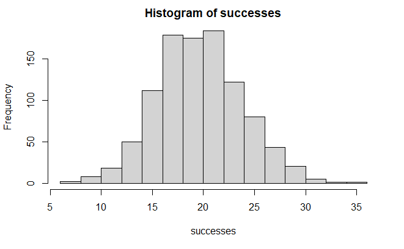

## Problem 10

For fair sided dice, the probability of any of the numbers 1 to 6 being rolled is $\frac{1}{6}$. We can consider the two dice to be independent, so the the probability of rolling a 6 on both is $\frac{1}{6}^2$; since the probability of rolling any number on a fair die is the same, the probability of rolling a 3 on both dice is also $\frac{1}{6}^2$. The second roll of dice is independent of the first, making the probability of rolling pairs of 6’s twice in a row $\frac{1}{6}^4$; this is true for rolling pairs of 3’s twice in a row as well, so both observed roll patterns have $\frac{1}{1296}$ probability, and are just as probable.

## Problem 11

1. $0$, since the lowest outcome on each die is a roll of 1; the sum of two dice can never be 1.
2. A sum of 5 can be composed of the following ordered roll pairs $(1,4),(2,3),(3,2),(4,1)$. Each of these pairs occur with probability $\frac{1}{36}$, making the total probability of observing a sum of 5 $\frac{4}{36}=\frac{1}{9}$.
3. A sum of 12 can only occur if both dice result in 6; this probability is thus $\frac{1}{6}^2 = \frac{1}{36}$.

## Problem 12

1. No, since there are individuals who are in both categories; this makes the categories nondisjoint by definition.

```r
library(VennDiagram)
grid.newpage()
venn.plot <- draw.pairwise.venn(area1      = .146,
                                area2      = .207,
                                cross.area = .042,
                                category   = c("Below poverty line", "Speak foreign language at home"),
                                cat.pos = 0,
                                cat.dist = .035,
                                scaled     = FALSE)
```

[output not shown]

## Problem 13

We can apply Bayes’ rule to solve.
$$\text{P[Condition|+]} = \frac{\text{P[+|Condition]}*\text{P[Condition]}}{\text{P[+|Condition]}*\text{P[Condition]}+\text{P[+|No Condition]}*\text{P[No Condition]}}$$
Given the information on proportion of people who have the condition and test accuracy for people with and without the condition, we obtain

$$\text{P[Condition|+]} = \frac{(.99)*(.03)}{(.99)*(.03)+(1-.98)*(1-.03)} = \frac{(.0297)}{(.0297)+(.0194)} = 0.605$$
So given that a randomly selected person tests positive for the predisposition, they have a 60.48% probability of actually having the predisposition.

## Problem 14

We can again apply Bayes’ rule to solve.
$$\text{P[In Favor|Degree]} = \frac{\text{P[Degree|In Favor]}*\text{P[In Favor]}}{\text{P[Degree|In Favor]}*\text{P[In Favor]}+\text{P[Degree|Against]}*\text{P[Against]}}$$
Using the provided information,
$$\text{P[In Favor|Degree]} = \frac{(.37)*(.53)}{(.37)*(.53)+(.44)*(1-.53)} = \frac{(.1961)}{(.1961) + (.2068)} = .487$$

So given that a random exit poll participant had a college degree, there is a 48.67% probability that they voted in favor of Scott Walker.